# COVID-19’s gendered impact on academic productivity

Megan Frederickson

28/04/2020

With schools and daycares closed because of COVID-19, many academics are currently working from home with their kids underfoot. Writing in Nature, Minello (https://www.nature.com/articles/d41586-020-01135-9) suggested the pandemic is disproportionately affecting the productivity of female academics, because women often do more caregiving than men.

I quantified this effect by analyzing data on preprint submissions to arXiv (https://arxiv.org/) and bioRxiv (https://www.biorxiv.org/), two preprint servers that together cover many STEM fields. Peer review takes time, so it is still too soon to see COVID-19’s effects on the numbers of journal articles published by female versus male academics. However, a growing number of academics make their submitted or in-progress manuscripts available on preprint servers, meaning it might be possible to measure the pandemic’s effect on preprint submissions in real time.

## arXiv submissions

First, I scraped submission data from arXiv, a preprint server for physics, math, computer science, statistics, and other quantitative disciplines. I used the aRxiv package to scrape the data, see:

Karthik, R. and K. Broman (2019). aRxiv: Interface to the arXiv API. R package version 0.5.19. https://CRAN.R-project.org/package=aRxiv

I began by scraping all records for March 15-April 15, 2020, during the COVID-19 pandemic, and for the same date range in 2019. I then expanded to the same dates in 2018. Finally, I scraped all the data for Jan. 1-March 15, 2020, immediately before the pandemic, and updated the pandemic data with the most recent dates (April 16-22, 2020). I scraped the data in batches, as recommended in the aRxiv package tutorial.

```r
#Not run
#Get all submissions between March 15, 2020 and April 15, 2020 (during the COVID-19 pandemic)
n.2020 <- arxiv_count(query = 'submittedDate:[20200315 TO 20200415]')
n.2020.1 <- arxiv_count(query = 'submittedDate:[20200315 TO 20200321]') #Check number in date range
df.2020.1 <- arxiv_search(query = 'submittedDate:[20200315 TO 20200321]', limit=n.2020, batchsize=1000)
n.2020.1-length(df.2020.1$id) #Check that the right number of records were returned
n.2020.2 <- arxiv_count(query = 'submittedDate:[20200322 TO 20200328]')
df.2020.2 <- arxiv_search(query = 'submittedDate:[20200322 TO 20200328]', limit=n.2020, batchsize=1000)
n.2020.2-length(df.2020.2$id)
n.2020.3 <- arxiv_count(query = 'submittedDate:[20200329 TO 20200403]')
df.2020.3 <- arxiv_search(query = 'submittedDate:[20200329 TO 20200403]', limit=n.2020, batchsize=1000)
n.2020.3-length(df.2020.3$id)
n.2020.4 <- arxiv_count(query = 'submittedDate:[20200404 TO 20200409]')
df.2020.4 <- arxiv_search(query = 'submittedDate:[20200404 TO 20200409]', limit=n.2020, batchsize=1000)
n.2020.4-length(df.2020.4$id)
n.2020.5 <- arxiv_count(query = 'submittedDate:[20200410 TO 20200412]')
df.2020.5 <- arxiv_search(query = 'submittedDate:[20200410 TO 20200412]', limit=2000, batchsize=500)
n.2020.5-length(df.2020.5$id)
n.2020.6 <- arxiv_count(query = 'submittedDate:[20200413 TO 20200415]')
df.2020.6 <- arxiv_search(query = 'submittedDate:[20200413 TO 20200415]', limit=2000, batchsize=500)
n.2020.6-length(df.2020.6$id)
df.2020.full <- rbind(df.2020.1, df.2020.2, df.2020.3, df.2020.4, df.2020.5, df.2020.6)
n.2020-length(df.2020.full$id)
write.csv(df.2020.full, file="arxiv_2020_data.csv")

#Get all submission between March 15, 2019 and April 15, 2019 (the same dates last year)
n.2019 <- arxiv_count(query = 'submittedDate:[20190315 TO 20190415]')
n.2019.1 <- arxiv_count(query = 'submittedDate:[20190315 TO 20190322]')
df.2019.1 <- arxiv_search(query = 'submittedDate:[20190315 TO 20190322]', limit=n.2019, batchsize=2000)
n.2019.1-length(df.2019.1$id)
n.2019.2 <- arxiv_count(query = 'submittedDate:[20190323 TO 20190329]')
df.2019.2 <- arxiv_search(query = 'submittedDate:[20190323 TO 20190329]', limit=n.2019, batchsize=2000)
n.2019.2-length(df.2019.2$id)
n.2019.3 <- arxiv_count(query = 'submittedDate:[20190330 TO 20190405]')
df.2019.3 <- arxiv_search(query = 'submittedDate:[20190330 TO 20190405]', limit=n.2019, batchsize=2000)
n.2019.3-length(df.2019.3$id)
n.2019.4 <- arxiv_count(query = 'submittedDate:[20190406 TO 20190412]')
df.2019.4 <- arxiv_search(query = 'submittedDate:[20190406 TO 20190412]', limit=n.2019, batchsize=2000)
n.2019.4-length(df.2019.4$id)
n.2019.5 <- arxiv_count(query = 'submittedDate:[20190413 TO 20190415]')
df.2019.5 <- arxiv_search(query = 'submittedDate:[20190413 TO 20190415]', limit=n.2019, batchsize=2000)
n.2019.5-length(df.2019.5$id)
df.2019.full <- rbind(df.2019.1, df.2019.2, df.2019.3, df.2019.4, df.2019.5)
n.2019-length(df.2019.full$id)
write.csv(df.2019.full, file="arxiv_2019_data.csv")

#Get all submissions between March 15, 2018 and April 15, 2018 (same dates two years ago)
n.2018 <- arxiv_count(query = 'submittedDate:[20180315 TO 20180415]')
n.2018.1 <- arxiv_count(query = 'submittedDate:[20180315 TO 20180321]')
df.2018.1 <- arxiv_search(query = 'submittedDate:[20180315 TO 20180321]', limit=n.2018, batchsize=2000)
n.2018.1-length(df.2018.1$id)
n.2018.2 <- arxiv_count(query = 'submittedDate:[20180322 TO 20180403]')
df.2018.2 <- arxiv_search(query = 'submittedDate:[20180322 TO 20180403]', limit=n.2018, batchsize=2000)
n.2018.2-length(df.2018.2$id)
n.2018.3 <- arxiv_count(query = 'submittedDate:[20180404 TO 20180409]')
df.2018.3 <- arxiv_search(query = 'submittedDate:[20180404 TO 20180409]', limit=n.2018, batchsize=2000)
n.2018.3-length(df.2018.3$id)
n.2018.4 <- arxiv_count(query = 'submittedDate:[20180410 TO 20180415]')
df.2018.4 <- arxiv_search(query = 'submittedDate:[20180410 TO 20180415]', limit=2000, batchsize=2000)
n.2018.4-length(df.2018.4$id)
df.2018.full <- rbind(df.2018.1, df.2018.2, df.2018.3, df.2018.4)
n.2018-length(df.2018.full$id)
write.csv(df.2018.full, file="arxiv_2018_data.csv")

#Get all submissions between Jan. 1, 2020 and March 15, 2020 (before COVID-19 pandemic)
n.early2020 <- arxiv_count(query = 'submittedDate:[20200101 TO 20200315]')
n.early2020.1 <- arxiv_count(query = 'submittedDate:[20200101 TO 20200115]')
df.early2020.1 <- arxiv_search(query = 'submittedDate:[20200101 TO 20200115]', limit=n.early2020, batchsize=2000)
n.early2020.1 - length(df.early2020.1$id)
n.early2020.2 <- arxiv_count(query = 'submittedDate:[20200116 TO 20200131]')
df.early2020.2 <- arxiv_search(query = 'submittedDate:[20200116 TO 20200131]', limit=n.early2020, batchsize=2000)
n.early2020.2 - length(df.early2020.2$id)
n.early2020.3 <- arxiv_count(query = 'submittedDate:[20200201 TO 20200215]')
df.early2020.3 <- arxiv_search(query = 'submittedDate:[20200201 TO 20200215]', limit=n.early2020, batchsize=2000)
n.early2020.3 - length(df.early2020.3$id)
n.early2020.4 <- arxiv_count(query = 'submittedDate:[20200216 TO 20200229]')
df.early2020.4 <- arxiv_search(query = 'submittedDate:[20200216 TO 20200229]', limit=n.early2020, batchsize=2000)
n.early2020.4 - length(df.early2020.4$id)
n.early2020.5 <- arxiv_count(query = 'submittedDate:[20200301 TO 20200315]')
df.early2020.5 <- arxiv_search(query = 'submittedDate:[20200301 TO 20200315]', limit=n.early2020, batchsize=2000)
n.early2020.5 - length(df.early2020.5$id)
df.early2020.full <- rbind(df.early2020.1, df.early2020.2, df.early2020.3, df.early2020.4, df.early2020.5)
n.early2020-length(df.early2020.full$id)
write.csv(df.early2020.full, file="arxiv_early2020_data.csv")

#Get all submissions between Apr. 16, 2020 and April 22, 2020 (update analysis with most recent data)
n.update <- arxiv_count(query = 'submittedDate:[20200416 TO 20200422]')
df.update <- arxiv_search(query = 'submittedDate:[20200416 TO 20200422]', limit=n.update, batchsize=2000)
n.update - length(df.update$id)
write.csv(df.update, file="arxiv_update2020_data.csv")
```

Next, I assigned gender to author names using the gender package, see:

Mullen, L. (2019). gender: Predict Gender from Names Using Historical Data. R package version 0.5.3, https://github.com/ropensci/gender.

This package returns the probability that a name is male or female by comparing the name to names in a database; I used the U.S. Social Security baby names database.

Please note: this is a brute force method of predicting gender, and it has many limitations, as discussed by the package authors on their GitHub repo and included links. By using this method, I am not assuming that individuals are correctly gendered in the resulting dataset, but merely that it provides insight into gender’s effects in aggregate across the population of preprint authors. This approach clearly mis-genders or excludes some individual authors, but it can reveal gender bias in a large enough dataset.

I predicted the genders of all preprint authors, and summarized the data as the number of male and female authors of each preprint, regardless of author order. This code takes a while to run, so it is not run when knitting this markdown document.

```r
#Not run
#First compbine data for year-by-year comparison
df.2020 <- read.csv("Data/arxiv_2020_data.csv") #Read in data
df.2019 <- read.csv("Data/arxiv_2019_data.csv")
df.2018 <- read.csv("Data/arxiv_2018_data.csv")
df.full <- rbind(df.2018, df.2019, df.2020) #Combine in one dataframe

#Next combine data for 2020 comparison
df.early2020 <- read.csv("Data/arxiv_early2020_data.csv")
df.update <- read.csv("Data/arxiv_update2020_data.csv")
df.all2020 <- rbind(df.2020, df.early2020, df.update[, -1]) #Combine in one dataframe

split.names <- function(x){strsplit(as.character(x), "|", fixed=TRUE)} #Write a function to split strings of author names

#For the year over year dataset
df.full$split.names <- lapply(df.full$authors, split.names) #Apply function

all_first_names <- word(unlist(df.full$split.names),1) #Make a list of all first author names
gender <- gender(all_first_names, method = "ssa") #Assign gender
gender <- unique(gender[ , c(1,2,4)]) #Keep only unique names

#This loop is an inelegant way of counting the number of male and female authors for each paper
tmp <- NULL
for(i in 1:length(df.full$authors)){
  tmp <- as.data.frame(word(unlist(df.full$split.names[[i]]), 1))
  colnames(tmp) <- "name"
  tmp <- merge(tmp, gender, by="name", all.x=TRUE, all.y=FALSE)
  df.full$male.n[i] <- sum(as.numeric(str_count(as.character(tmp$gender), pattern = paste(sprintf("\\b%s\\b", "male")))), na.rm=TRUE)
  df.full$female.n[i] <-  sum(as.numeric(str_count(as.character(tmp$gender), pattern = paste(sprintf("\\b%s\\b", "female")))), na.rm=TRUE)
}

df.full.output <- as.data.frame(apply(df.full,2,as.character))
write.csv(df.full.output, "arxiv_full_gender.csv")

#Same for the all 2020 dataset
df.all2020$split.names <- lapply(df.all2020$authors, split.names)

tmp <- NULL
all_first_names <- word(unlist(df.all2020$split.names),1)
head(all_first_names)
gender <- gender(all_first_names, method = "ssa")
gender <- unique(gender[ , c(1,2,4)])

for(i in 1:length(df.all2020$authors)){
  tmp <- as.data.frame(word(unlist(df.all2020$split.names[[i]]), 1))
  colnames(tmp) <- "name"
  tmp <- merge(tmp, gender, by="name", all.x=TRUE, all.y=FALSE)
  df.all2020$male.n[i] <- sum(as.numeric(str_count(as.character(tmp$gender), pattern = paste(sprintf("\\b%s\\b", "male")))), na.rm=TRUE)
  df.all2020$female.n[i] <- sum(as.numeric(str_count(as.character(tmp$gender), pattern = paste(sprintf("\\b%s\\b", "female")))), na.rm=TRUE)
}

df.all2020.output <- as.data.frame(apply(df.all2020,2,as.character))
write.csv(df.all2020.output, "arxiv_all2020_gender.csv")
```

### All arXiv authors

How many male versus female authors of preprints were there in Mar/Apr, 2020, compared to the same dates last year?

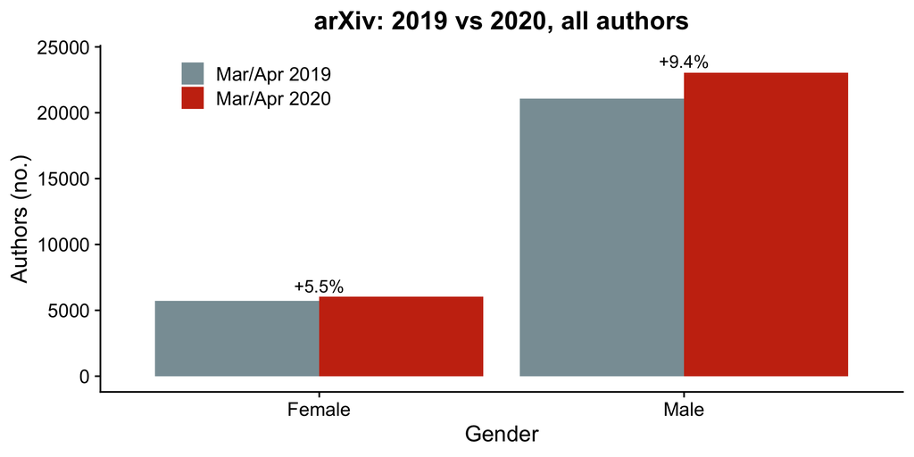

```r
df.full <- read.csv("Data/arxiv_full_gender.csv") #Read in data
df.full <- df.full[!duplicated(df.full), ] #Remove duplicates
df.full$year <- as.factor(year(as.Date(df.full$submitted))) #Extract year

all <- as.data.frame(ungroup(df.full %>% group_by(year) %>% summarize(Female = sum(female.n, na.rm=TRUE), Male = sum(male.n, na.rm=TRUE)))) #Summarize by year
all$total <- all$Female+all$Male #Total autthors
all.long <- gather(all, Gender, number, Male:Female) #Make wide data long
all.t <- as.data.frame(t(all[,-1])) #Transpose
colnames(all.t) <- c("2018", "2019", "2020") #Fix column names
all.t$per.dif.1920 <- (all.t$`2020`/all.t$`2019`*100)-100 #Calculate percent change, 2020 over 2019

#Just compare 2019 and 2020
p1 <- ggplot(data=subset(all.long, year != 2018), aes(fill=as.factor(year), y=number, x=Gender))+geom_bar(position="dodge", stat="identity")+theme_cowplot()+xlab("Gender")+ylab("Authors (no.)")+labs(fill="Year")+scale_fill_manual(values = wes_palette("Royal1"), labels=c("Mar/Apr 2019", "Mar/Apr 2020"))+ggtitle("arXiv: 2019 vs 2020, all authors")+theme(legend.position = c(0.1, 0.9), legend.title = element_blank(), plot.title = element_text(hjust = 0.5))+annotate("text", x=c(1, 2),  y=c(6850,23900), label = paste0("+", round(all.t$per.dif.1920[1:2], 1), "%"))
p1
```

arXiv preprint submissions are up overall, but the number of male authors is currently growing faster than the number of female authors. Comparing preprint submissions in late March and early April 2020 to the same dates in 2019, the number of male authors has grown more than the number of female authors, both as a percent change and in absolute terms.

### Sole arXiv authors

How many arXiv preprints were sole-authored by a male versus a female academic in Mar/Apr, 2020, compared to the same dates last year?

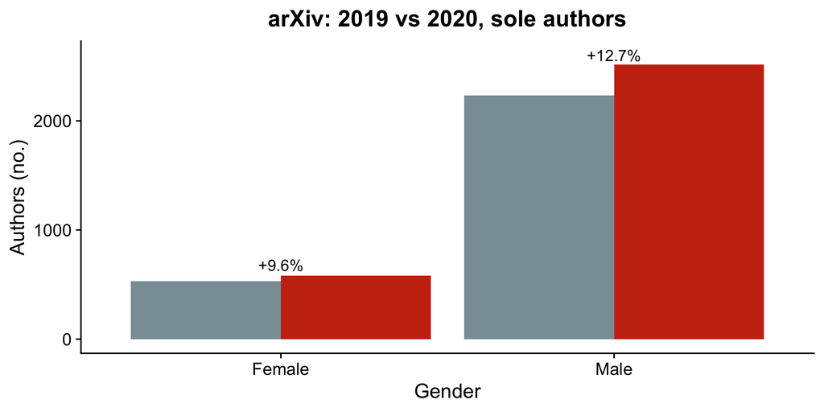

```r
summary <- as.data.frame(ungroup(df.full %>% group_by(year, male.n, female.n) %>% summarize(n = n())))
summary$total.n <- summary$male.n+summary$female.n
summary.sole.authors <- subset(summary, total.n == 1)
sole.wide <- spread(summary.sole.authors, year, n)
sole.wide$gender <- ifelse(sole.wide$male.n == 0, "Female", "Male")
sole.long <- gather(sole.wide, year, number, `2018`:`2020`)
sole.wide$per.dif.1920 <- (sole.wide$`2020`/sole.wide$`2019`)*100-100

p2 <- ggplot(data=subset(sole.long, year != 2018), aes(fill=as.factor(year), y=number, x=gender))+geom_bar(position="dodge", stat="identity")+theme_cowplot()+xlab("Gender")+ylab("Authors (no.)")+labs(fill="Year")+scale_fill_manual(values = wes_palette("Royal1"), labels=c("Mar/Apr 2019", "Mar/Apr 2020"))+ggtitle("arXiv: 2019 vs 2020, sole authors")+theme(legend.position = c(0.1, 0.9), legend.title = element_blank(), plot.title = element_text(hjust = 0.5))+annotate("text", x=c(1, 2),  y=c(680,2600), label = paste0("+", round(sole.wide$per.dif.1920[1:2], 1), "%"))+theme(legend.position="none")
p2
```

Single-authored arXiv submissions are also up overall, but again the number of male authors is currently growing faster than the number of female authors, again both as a percent change and in absolute terms.

### arXiv: pre- and during-COVID-19 in the year 2020

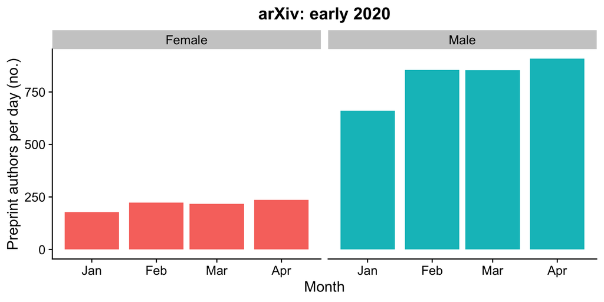

```r
#All authors
df.all2020 <- read.csv("Data/arxiv_all2020_gender.csv") #Read in data
df.all2020 <- df.all2020[!duplicated(df.all2020), ] #Remove duplicated removes

df.all2020$month <- floor_date(as.Date(df.all2020$submitted), "month") #Bin by month
arxiv.m <- as.data.frame(ungroup(subset(df.all2020) %>% group_by(month) %>% summarize(female.n=sum(female.n, na.rm=TRUE), male.n=sum(male.n, na.rm=TRUE),n.days = length(unique(as.Date(submitted)))))) #Summarize by month
arxiv.m.long <- gather(arxiv.m, gender, n, female.n:male.n) #Make wide data long
arxiv.m.long$pubs.per.day <- arxiv.m.long$n/arxiv.m.long$n.days #Adjust for different numbers of days in each month
arxiv.m.long$gender <- as.factor(arxiv.m.long$gender) #Make sure gender is a factor
levels(arxiv.m.long$gender) <- c("Female", "Male") #Capitalize genders

p3 <- ggplot(data=arxiv.m.long, aes(fill=gender, y=pubs.per.day, x=month))+geom_bar(position="dodge", stat="identity")+theme_cowplot()+ggtitle("arXiv: early 2020")+xlab("Month")+ylab("Preprint authors per day (no.)")+labs(fill="Gender")+facet_grid(~gender)+theme(legend.position="none", plot.title = element_text(hjust = 0.5))
p3
```

The numbers of male authors of arXiv preprints have increased through early 2020, while numbers of female authors of arXiv preprints have basically plateaued during the pandemic.

## bioRxiv submissions

Next, I scraped submission data from bioRxiv (https://biorxiv.org/), which is the main preprint server for biology. I used the rbiorxiv package, see:

Fraser, N (2020). rbiorxiv. R package, https://github.com/nicholasmfraser/rbiorxiv

I scraped all records for March 15-April 15, 2020, during the COVID-19 pandemic, and for the same date range in 2019 and 2018. I then expanded to all of 2020, up to April 22, 2020.

```r
#Not run
#Get all submissions between March 15, 2020 and April 15, 2020 (during the COVID-19 pandemic)
df.b.2020 <- biorxiv_content(from = "2020-03-15", to = "2020-04-15", limit = "*", format = "df")
df.b.2020.6 <- biorxiv_content(from = "2020-04-16", to = "2020-04-22", limit = "*", format = "df")
#Get all submissions between Jan. 1, 2019 and Mar 15, 2020 (before the COVID-19 pandemic)
df.b.2020.2 <- biorxiv_content(from = "2020-02-15", to = "2020-02-29", limit = "*", format = "df")
df.b.2020.3 <- biorxiv_content(from = "2020-03-01", to = "2020-03-15", limit = "*", format = "df")
df.b.2020v2 <- rbind(df.b.2020.2, df.b.2020.3)
df.b.2020.4 <- biorxiv_content(from = "2020-01-15", to = "2020-02-15", limit = "*", format = "df")
df.b.2020.5 <- biorxiv_content(from = "2020-01-01", to = "2020-01-14", limit = "*", format = "df")
#Get all submissions for same dates in 2019
df.b.2019 <- biorxiv_content(from = "2019-03-15", to = "2019-04-15", limit = "*", format = "df")
#Get all submissions for same dates in 2018
df.b.2018 <- biorxiv_content(from = "2018-03-15", to = "2018-04-15", limit = "*", format = "df")

write.csv(df.b.2019, "biorxiv_2019_data.csv")
write.csv(df.b.2020, "biorxiv_2020_data.csv")
write.csv(df.b.2018, "biorxiv_2018_data.csv")
write.csv(df.b.2020v2, "biorxiv_FebMar2020_data.csv")
write.csv(df.b.2020.4, "biorxiv_JanFeb2020_data.csv")
write.csv(df.b.2020.5, "biorxiv_earlyJan2020_data.csv")
write.csv(df.b.2020.6, "biorxiv_Apr16toApr22_data.csv")
```

I then inferred the gender of corresponding authors of bioRxiv preprints, as above. Note that the bioRxiv API only returns first author names for the corresponding authors, and not for all authors. (Unfortunately.)

```r
df.b.2018 <- read.csv("Data/biorxiv_2018_data.csv")
df.b.2019 <- read.csv("Data/biorxiv_2019_data.csv")
df.b.2020 <- read.csv("Data/biorxiv_2020_data.csv")
df.b.2020v1 <- read.csv("Data/biorxiv_earlyJan2020_data.csv")
df.b.2020v2 <- read.csv("Data/biorxiv_FebMar2020_data.csv")
df.b.2020v3 <- read.csv("Data/biorxiv_JanFeb2020_data.csv")
df.b.2020v4 <- read.csv("Data/biorxiv_Apr16toApr22_data.csv")

df.b.full <- rbind(df.b.2018, df.b.2019, df.b.2020)
df.b.all2020 <- rbind(df.b.2020v2, df.b.2020v3, df.b.2020v4, df.b.2020v1, df.b.2020)

df.b.full$year <- as.factor(year(as.Date(df.b.full$date)))

df.b.all2020$date <- as.Date(df.b.all2020$date)

df.b.full$cor.author.first.name <- sapply(strsplit(as.character(df.b.full$author_corresponding), " "), head, 1) #Extract first names
df.b.all2020$cor.author.first.name <- sapply(strsplit(as.character(df.b.all2020$author_corresponding), " "), head, 1) #Extract first names

gender <- NULL
gender <- gender(df.b.full$cor.author.first.name, method = "ssa")
gender <- unique(gender[ , c(1,2,4)])
df.b.full <- merge(df.b.full, gender, by.x = "cor.author.first.name",  by.y ="name", all = TRUE)

df.b.full <- df.b.full[!duplicated(df.b.full),]

gender <- NULL
gender <- gender(df.b.all2020$cor.author.first.name, method = "ssa")
gender <- unique(gender[ , c(1,2,4)])
df.b.all2020 <- merge(df.b.all2020, gender, by.x = "cor.author.first.name",  by.y ="name", all = TRUE)

df.b.all2020 <- df.b.all2020[!duplicated(df.b.all2020),]
```

I compared the numbers of male and female corresponding authors on bioRxiv preprints between Mar/Apr 2019 and 2020.

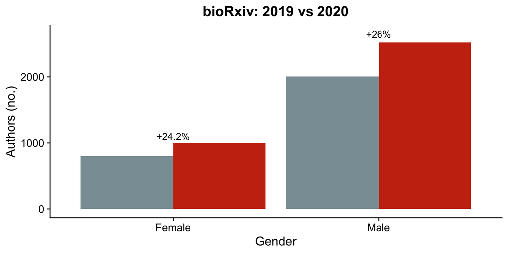

```r
biorxiv.yr <- as.data.frame(ungroup(subset(df.b.full, !is.na(gender)) %>% group_by(year, gender) %>% summarize(n=n())))
biorxiv.yr.wide <- spread(biorxiv.yr, year, n)
biorxiv.yr.wide$gender <- as.factor(biorxiv.yr.wide$gender)
levels(biorxiv.yr.wide$gender) <- c("Female", "Male")
biorxiv.yr.long <- gather(biorxiv.yr.wide, year, number, `2018`:`2020`)
biorxiv.yr.long$year <- as.factor(biorxiv.yr.long$year)
biorxiv.yr.wide$per.dif.1920 <- (biorxiv.yr.wide$`2020`/biorxiv.yr.wide$`2019`)*100-100

p4 <- ggplot(data=subset(biorxiv.yr.long, year != 2018), aes(fill=as.factor(year), y=number, x=as.factor(gender)))+geom_bar(position="dodge", stat="identity")+theme_cowplot()+xlab("Gender")+ylab("Authors (no.)")+labs(fill="Year")+scale_fill_manual(values = wes_palette("Royal1"))+ggtitle("bioRxiv: 2019 vs 2020")+theme(plot.title = element_text(hjust = 0.5))+annotate("text", x=c(1,2),  y=c(1100,2650), label = paste0("+", round(biorxiv.yr.wide$per.dif.1920, 1), "%"))+theme(legend.position="none")
p4
```

```r
p5 <- plot_grid(p1, p2, p4, nrow=1) #Combine into part of a single figure
```

The gender difference among corresponding authors for bioRxiv preprints is more modest than in the arXiv analysis, but the number of male corresponding authors of bioRxiv preprints has still increased more than the number of female corresponding authors of bioRxiv preprints, year over year.

### bioRxiv: pre- and during-COVID-19 in the year 2020

As for arXiv submissions, I also compared bioRxiv submissions across months for early 2020.

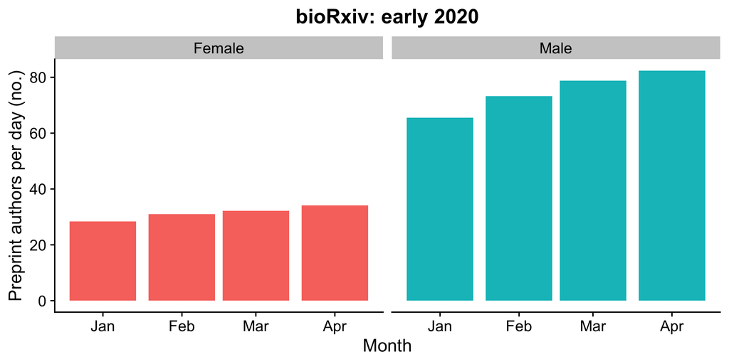

```r
df.b.all2020$month <- floor_date(df.b.all2020$date, "month")
biorxiv.m <- as.data.frame(ungroup(subset(df.b.all2020, !is.na(gender)) %>% group_by(month, gender) %>% summarize(n=n(), n.days = length(unique(date)), pubs.per.day = n/n.days)))
biorxiv.m$gender <- as.factor(biorxiv.m$gender)
levels(biorxiv.m$gender) <- c("Female", "Male")

p6 <- ggplot(data=biorxiv.m, aes(fill=gender, y=pubs.per.day, x=month))+geom_bar(position="dodge", stat="identity")+theme_cowplot()+ggtitle("bioRxiv: early 2020")+xlab("Month")+ylab("Preprint authors per day (no.)")+facet_grid(~gender)+theme(legend.position="none", plot.title = element_text(hjust = 0.5))
p6
```

```r
p7 <- plot_grid(p3, p6, nrow=1) #Combine into part of a single figure
```

The numbers of male authors of bioRxiv preprints have increased steadily through early 2020, while numbers of female authors of bioRxiv preprints have increased only slightly.

I put it all together in a single figure.

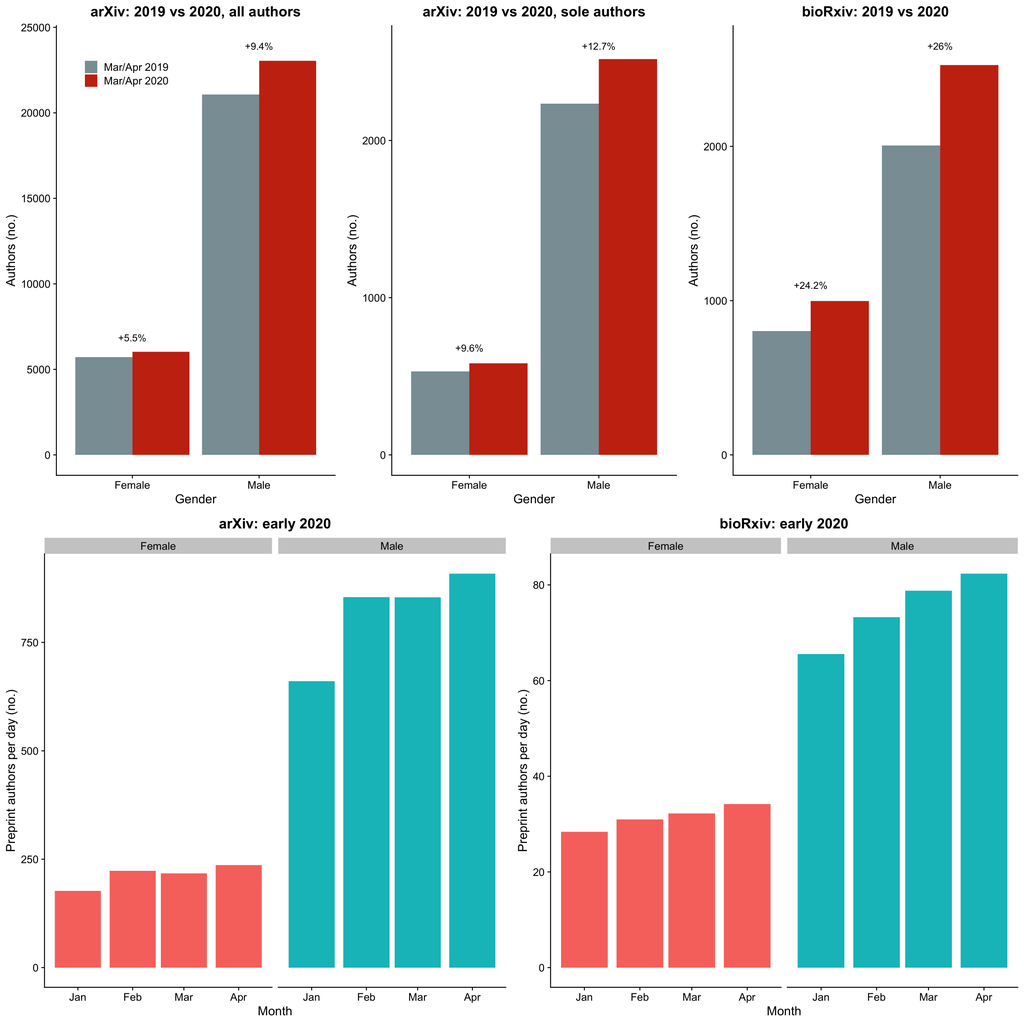

```r
p8 <- plot_grid(p5, p7, nrow=2)
p8
```

```r
save_plot("figure.png", p8, base_height=16, base_width=16)
```

Throughout this analysis, effects are conservative because many preprints describe research completed months ago. However, the trends in both preprint servers are consistent with the hypothesis that the pandemic is disproportionately hurting the productivity of female scholars. How long this effect will persist, and what its downstream consequences might be for journal publications and academic careers, are open questions. In summary, in a ‘publish or perish’ world, it seems this pandemic could be setting back the hard-won progress of women in STEM.